# GSE118614 Smart-Seq2

This is an analysis for the dataset GSE118614 made available by Clark BS et al. in their paper [*Single-cell RNA-Seq Analysis of Retinal Development Identifies NFI Factors as Regulating Mitotic Exit and Late-Born Cell Specification*](https://www.sciencedirect.com/science/article/abs/pii/S0896627319303459). We observe a seemingly conspicuous batch effect in figure 1B and figure S1E in their original report. Thus, we try to make a correction.

```r
rm(list=ls())
gc()
```

```
           used  (Mb) gc trigger   (Mb)   max used    (Mb)
Ncells  2700995 144.3    4929047  263.3    4929047   263.3
Vcells 64767981 494.2  565669176 4315.8 1498787721 11434.9
```

```r
library(Matrix)
library(ggplot2)
library(Rtsne)
library(matrixStats)
```

# Overview of the dataset

We first overview the dataset.

```r
barcode.path <- "../data/raw/GSE118614/GSE118614_Smart_cells.tsv.gz"
features.path <- "../data/raw/GSE118614/GSE118614_Smart_genes.tsv.gz"
matrix.path <- "../data/raw/GSE118614/GSE118614_Smart_aggregate.mtx.gz"
mat <- readMM(file = matrix.path)
feature.names = read.delim(features.path,
                           header = TRUE,
                           stringsAsFactors = FALSE)
barcode.names = read.delim(barcode.path,
                           header = TRUE,
                           stringsAsFactors = FALSE)
```

## Cell features

```r
barcode.names
```

|  | Cell_Name | Age | Plate | num_genes_expressed | Total_mRNAs | tSNE1_pos | tSNE2_pos | raw_cluster | CellType |
| --- | --- | --- | --- | --- | --- | --- | --- | --- | --- |
| q1_0 | E14_C01 | E14 | E14_Plate1 | 3321 | 14732 | 6.32755817 | 7.145754933 | 38 | Neurogenic Cells |
| q2_0 | E14_C02 | E14 | E14_Plate1 | 3445 | 15112 | 43.73134164 | 2.881545118 | 37 | Amacrine Cells |
| q3_0 | E14_C03 | E14 | E14_Plate1 | 3135 | 13932 | 25.51102720 | 24.931069438 | 31 | Early RPCs |
| q4_0 | E14_C04 | E14 | E14_Plate1 | 3290 | 14392 | 20.54598019 | -1.719829230 | 14 | Retinal Ganglion Cells |
| q5_0 | E14_C05 | E14 | E14_Plate1 | 1960 | 9116 | 24.90614178 | 29.860197627 | 26 | Early RPCs |
| q6_0 | E14_C06 | E14 | E14_Plate1 | 1935 | 8948 | 24.34329260 | 13.336287795 | 1 | Early RPCs |
| q7_0 | E14_C07 | E14 | E14_Plate1 | 3949 | 17280 | 18.51836511 | 33.359866778 | 40 | Early RPCs |
| q8_0 | E14_C08 | E14 | E14_Plate1 | 2949 | 13208 | 23.51206188 | -1.726738034 | 14 | Retinal Ganglion Cells |
| q9_0 | E14_C09 | E14 | E14_Plate1 | 1101 | 4404 | 20.72819184 | 35.238901381 | 40 | Early RPCs |
| q10_0 | E14_C10 | E14 | E14_Plate1 | 3608 | 16008 | 12.38586216 | 41.022716880 | 6 | Early RPCs |

[output cut: 737 more lines]

There are 3 time points, each has 3 plates. The original reports concludes that each time point has mostly unique cell types.

```r
table(barcode.names$Age)
```

```
E14 E18  P2
195 283 269
```

```r
table(barcode.names$Plate)
```

```
E14_Plate1 E14_Plate2 E14_Plate3 E18_Plate1 E18_Plate2 E18_Plate3  P2_Plate1  P2_Plate2  P2_Plate3
        74         52         69         95         94         94         91         87         91
```

```r
table(barcode.names$CellType)
```

```
          Amacrine Cells               Early RPCs        Intermediate RPCs                Late RPCs
                      15                      156                      227                      173
        Neurogenic Cells Photoreceptor Precursors   Retinal Ganglion Cells
                      52                      115                        9
```

```r
table(barcode.names$Age, barcode.names$CellType)
```

```
      Amacrine Cells Early RPCs Intermediate RPCs Late RPCs Neurogenic Cells Photoreceptor Precursors
  E14              7        154                 1         0               19                        5
  E18              8          1               221         1               32                       20
  P2               0          1                 5       172                1                       90

      Retinal Ganglion Cells
  E14                      9
  E18                      0
  P2                       0
```

```r
table(barcode.names$Plate, barcode.names$CellType)
```

```
             Amacrine Cells Early RPCs Intermediate RPCs Late RPCs Neurogenic Cells Photoreceptor Precursors
  E14_Plate1              5         50                 0         0               12                        0
  E14_Plate2              2         42                 0         0                4                        2
  E14_Plate3              0         62                 1         0                3                        3
  E18_Plate1              4          0                72         0               10                        9
  E18_Plate2              1          1                75         0               10                        7
  E18_Plate3              3          0                74         1               12                        4
  P2_Plate1               0          0                 1        51                0                       39
  P2_Plate2               0          1                 4        57                0                       25
  P2_Plate3               0          0                 0        64                1                       26

             Retinal Ganglion Cells
  E14_Plate1                      7
  E14_Plate2                      2
  E14_Plate3                      0
  E18_Plate1                      0
  E18_Plate2                      0
  E18_Plate3                      0
  P2_Plate1                       0
  P2_Plate2                       0
  P2_Plate3                       0
```

### tSNE plot using the given tSNE coordinates

It’s also not a bad idea to reproduce it for a fair comparison in the future. But let’s first look at the genes…

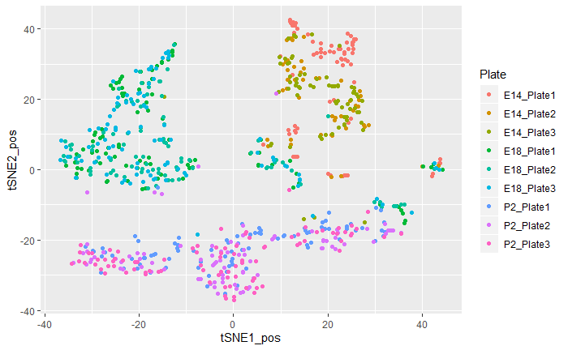

```r
ggplot(barcode.names) + geom_point(aes(x=tSNE1_pos, y=tSNE2_pos, color=Plate))
```

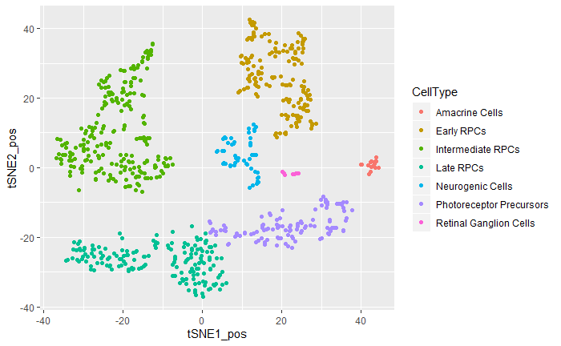

```r
ggplot(barcode.names) + geom_point(aes(x=tSNE1_pos, y=tSNE2_pos, color=CellType))
```

## Gene features

```r
feature.names
```

|  | gene_short_name | locus | num_cells_expressed | mean_expr | percent_detection | use_for_ordering |
| --- | --- | --- | --- | --- | --- | --- |
| ENSMUSG00000000001.4 | Gnai3 | chr3:108107279-108146146 | 354 | 1.233507e+00 | 47.3895582 | FALSE |
| ENSMUSG00000000003.12 | Pbsn | chrX:77837900-77853623 | 0 | 0.000000e+00 | 0.0000000 | FALSE |
| ENSMUSG00000000028.11 | Cdc45 | chr16:18780446-18835261 | 205 | 7.834930e-01 | 27.4431058 | FALSE |
| ENSMUSG00000000031.12 | H19 | chr7:142575528-142578143 | 95 | 1.675487e-01 | 12.7175368 | TRUE |
| ENSMUSG00000000037.13 | Scml2 | chrX:161117192-161258213 | 43 | 4.296459e-02 | 5.7563588 | FALSE |
| ENSMUSG00000000049.8 | Apoh | chr11:107933386-108414396 | 2 | 3.845789e-04 | 0.2677376 | FALSE |
| ENSMUSG00000000056.7 | Narf | chr11:121237252-121255856 | 239 | 6.604975e-01 | 31.9946452 | FALSE |
| ENSMUSG00000000058.6 | Cav2 | chr6:17197750-17385604 | 6 | 4.790741e-03 | 0.8032129 | FALSE |
| ENSMUSG00000000078.6 | Klf6 | chr13:5861488-5870393 | 246 | 3.718156e-01 | 32.9317269 | FALSE |
| ENSMUSG00000000085.13 | Scmh1 | chr4:120405280-120530186 | 125 | 3.158368e-01 | 16.7336011 | FALSE |

[output cut: 990 more lines]

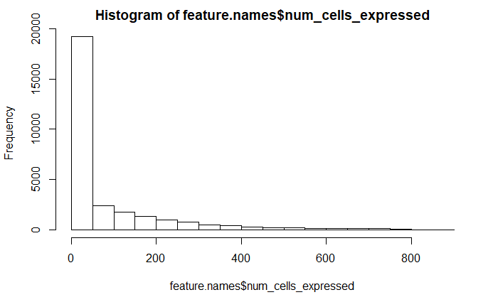

```r
hist(feature.names$num_cells_expressed)
```

```r
mat <- as.matrix(mat)
rownames(mat) <- barcode.names$Cell_Name
colnames(mat) <- rownames(feature.names)
```

tSNE-dimension reduction was performed on the top principal components learned from high variance genes in cells captured at individual time points. Mclust version 5.4 (Scrucca et al., 2016) was used to cluster cells in tSNE-space at which point cell type identity of clusters was assigned based on expression of known marker genes for either retinal or non-retinal tissue.

```r
th = 2

sum(feature.names$num_cells_expressed >= th)
```

```
[1] 16335
```

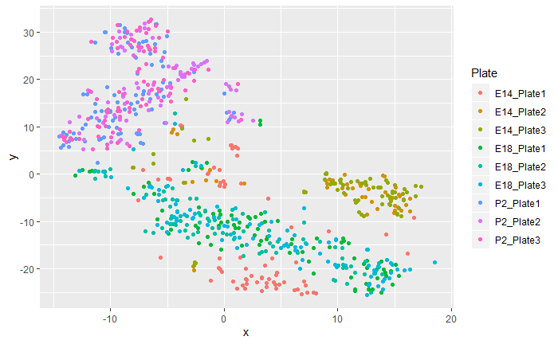

```r
#mat2 = t(t(mat) / colMeans(mat))

set.seed(0)
tsne_res <- Rtsne(log2(mat[, feature.names$num_cells_expressed > th] + 1), pca_scale=T)

tsne_plot <- data.frame(x = tsne_res$Y[, 1], y = tsne_res$Y[, 2], Plate = barcode.names$Plate)

ggplot(tsne_plot) + geom_point(aes(x=x, y=y, color=Plate))
```

```r
source("../R/varactor.R")
```

```r
obj <- Varactor$new(data = list(expr=t(mat)),
                    labels = list(expr = list(plate = barcode.names$Plate, type=barcode.names$CellType, age=barcode.names$Age)),
                    what = 'raw')
```

```
Now you are creating an R6 object.
If you want to make a copy for an R6 object, use 'a_copy <- this_one$clone()'.
```

```r
obj$normalize()
```

```
Normalizing data for each dataset...
Note that the nomalization is based all the genes available in each dataset.
```

```r
#obj$normalized <- obj$raw
obj$combine(sd_threshold = .0, cv_threshold = 0.5)
```

```
Combine data to one single dataset...
```

```r
obj$reduce(reduce_dim = 50)
```

```
Calculating PCA...
Dimensionality is set to 50. If this is not preferred provide a value for parameter reduce_dim
Depending on the data size, this may take a few minutes...
0 constant genes are not considered in PCA.
```

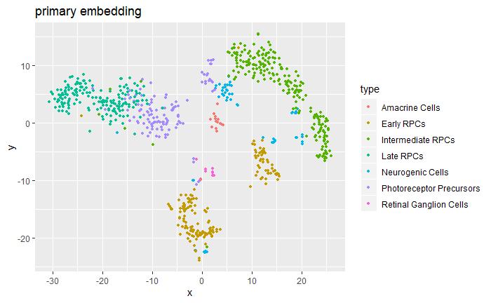

```r
set.seed(0)
obj$define_metric("primary", "euclidean")$measure("primary")$embed("primary", "tsne")
obj$plot("primary", "embedding", "type")
```

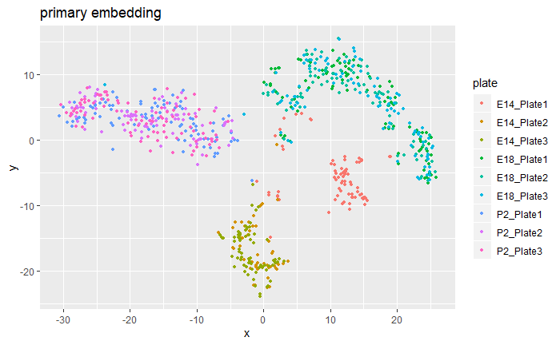

```r
obj$plot("primary", "embedding", "plate")
```

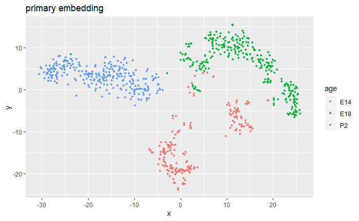

```r
obj$plot("primary", "embedding", "age")
```

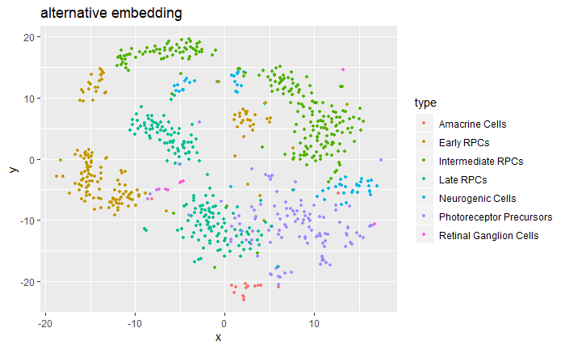

```r
set.seed(1)
obj$define_metric("alternative", "davidson", strata = 'plate')$measure("alternative")$embed("alternative", "tsne")
obj$plot("alternative", "embedding", "type")
```

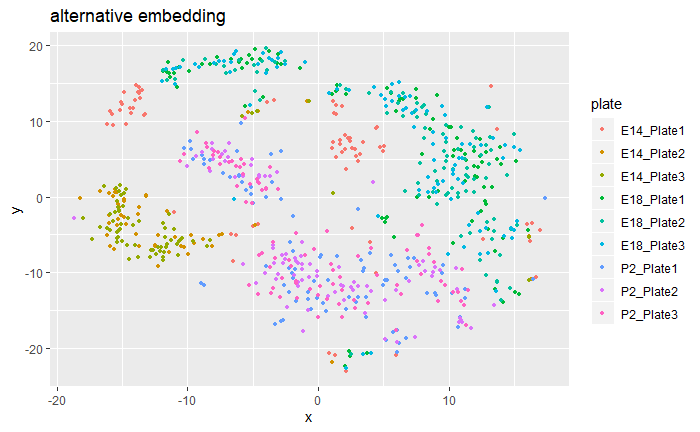

```r
obj$plot("alternative", "embedding", "plate")
```

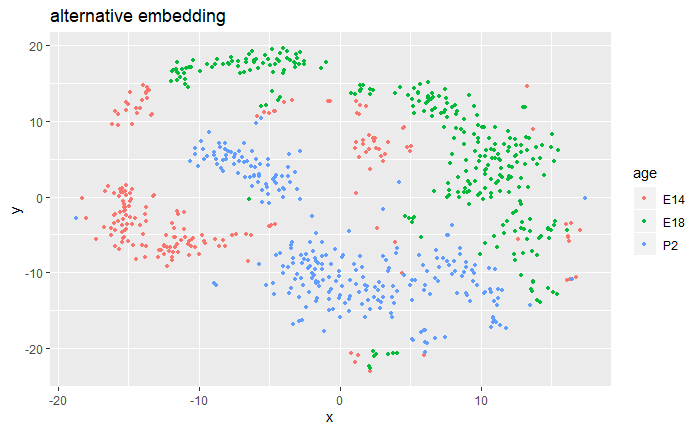

```r
obj$plot("alternative", "embedding", "age")
```

```r
obj$labels$type2 <- obj$labels$type
```

```
Note: You are changing the labels.
```

```r
obj$labels$type2[obj$labels$type2 %in% c('Early RPCs', 'Intermediate RPCs', 'Late RPCs')] = 'RPCs'
```

```
Note: You are changing the labels.
```

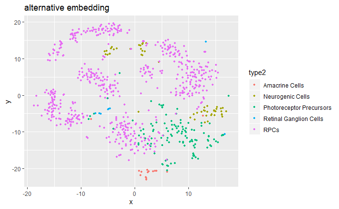

```r
obj$plot("alternative", "embedding", "type2")
```

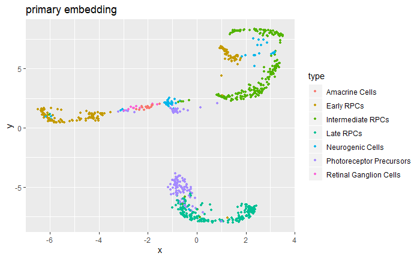

```r
set.seed(0)
obj$define_metric("primary", "euclidean")$measure("primary")$embed("primary", "umap")
obj$plot("primary", "embedding", "type")
```

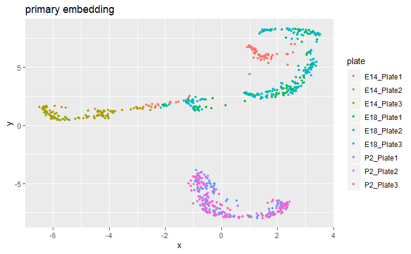

```r
obj$plot("primary", "embedding", "plate")
```

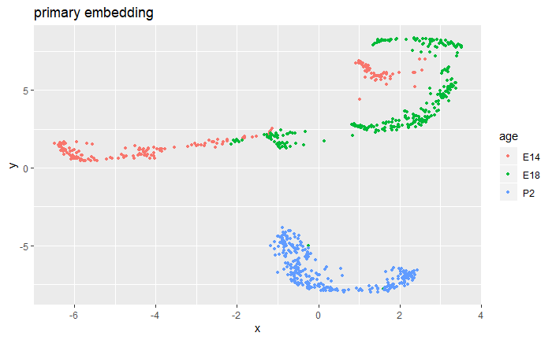

```r
obj$plot("primary", "embedding", "age")
```

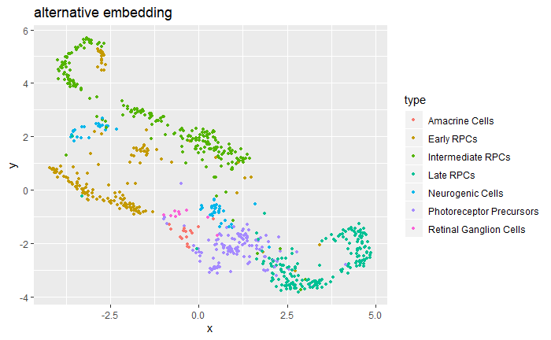

```r
obj$define_metric("alternative", "davidson", strata = 'plate')$measure("alternative")$embed("alternative", "umap")
obj$plot("alternative", "embedding", "type")
```

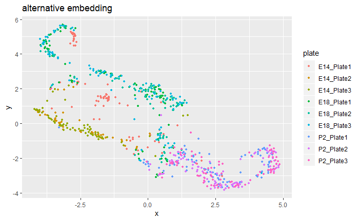

```r
obj$plot("alternative", "embedding", "plate")
```

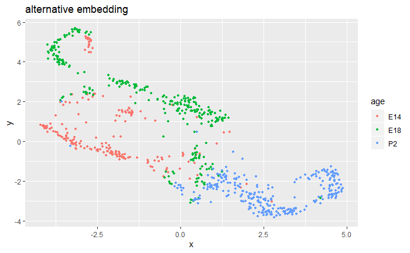

```r
obj$plot("alternative", "embedding", "age")
```

```r
obj$labels$type2 <- obj$labels$type
```

```
Note: You are changing the labels.
```

```r
obj$labels$type2[obj$labels$type2 %in% c('Early RPCs', 'Intermediate RPCs', 'Late RPCs')] = 'RPCs'
```

```
Note: You are changing the labels.
```

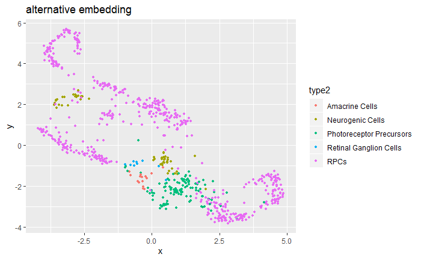

```r
obj$plot("alternative", "embedding", "type2")
```

```r
time_of_strata <- c(14, 14, 14, 18, 18, 18, 22, 22, 22)
names(time_of_strata) <- unique(obj$labels$plate)

time_of_strata
```

```
E14_Plate1 E14_Plate2 E14_Plate3 E18_Plate1 E18_Plate2 E18_Plate3  P2_Plate1  P2_Plate2  P2_Plate3
        14         14         14         18         18         18         22         22         22
```

```r
time_label <- time_of_strata[obj$labels$plate]
```

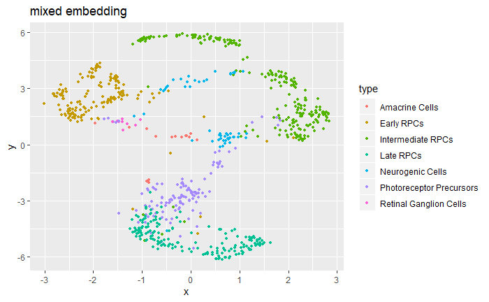

```r
obj$define_metric("mixed", "mixed_davidson", strata = 'plate', time_label = time_label, time_of_strata = time_of_strata, reg = 2., pow = 1.)$measure("mixed")$embed("mixed", "umap")
obj$plot("mixed", "embedding", "type")
```

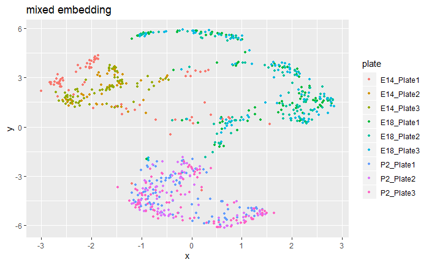

```r
obj$plot("mixed", "embedding", "plate")
```

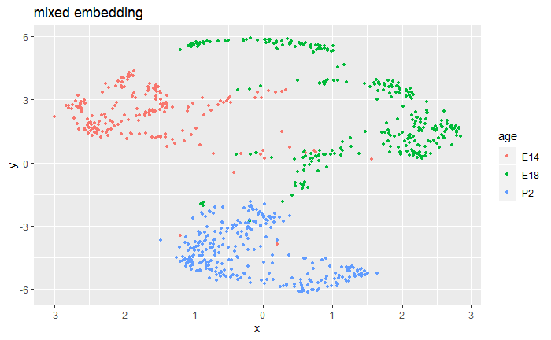

```r
obj$plot("mixed", "embedding", "age")
```

```r
obj$labels$type2 <- obj$labels$type
```

```
Note: You are changing the labels.
```

```r
obj$labels$type2[obj$labels$type2 %in% c('Early RPCs', 'Intermediate RPCs', 'Late RPCs')] = 'RPCs'
```

```
Note: You are changing the labels.
```

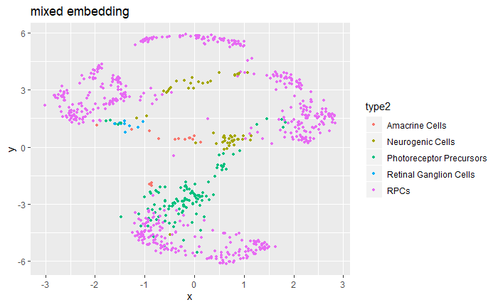

```r
obj$plot("mixed", "embedding", "type2")
```